# Appendix B: Validation

This appendix includes details of the validation procedure.

## Station Observations

The monthly CF were validated using a global observational dataset of synoptic weather reports collected at 5388 stations over 1971-2009 (Eastman and Warren 2012). We extracted the mean “total cloud” amount for each month, which represents the mean proportion of the sky that was covered by all types of cloud during the observations in that month. Comparison of these observations to satellite data must take into account that the sampling radius of these observations (the visible sky) depends on cloud height, cloud thickness, the curvature of the earth, and other factors, but is typically much larger than a single 1km MODIS pixel. We followed Dybbroe, Karlsson, and Thoss (2005) and took the mean monthly MODCF for a circle with 16km radius around each station location. Additionally, this converts the temporal MODCF to mean cloud amount within the sample radius to make it comparable to the station observations.

The monthly MODCF (including data from 2000-2013) were compared to station observations using linear models over the full station record (1970-2009) and the MODIS era (2000-2009) to assess accuracy and relevance of the 14-year satellite-derived data for estimating long-term monthly climatologies. For the full record comparison, the station dataset was filtered to include only stations with at least 20 observations per month for at least 20 years, which retained 4679 stations. Several countries (notably the USA, Canada, and New Zealand) converted from human cloud observations to automated laser ceilometers over the past decade leading to a decline in the number of observations over 1997-2009 (Eastman and Warren 2012). For the MODIS era comparison, we included only stations with at least 20 observations per month for the full 10-year period (2000-2009), so the number of stations available was reduced to 1558.

### Monthly Comparison

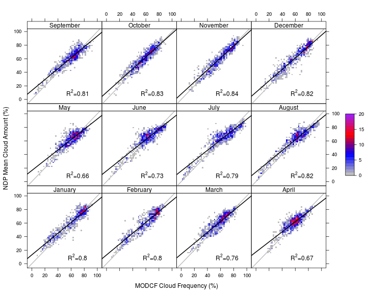

#### Spatial Distribution

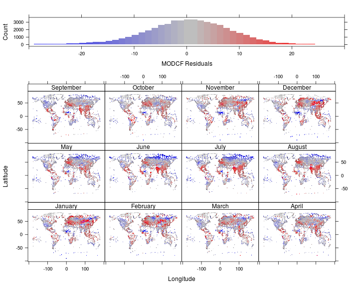

Histogram and spatial distribution of residuals from linear model between station and satellite cloud amount at station locations. Negative (positive) values indicate locations where MODCF was less than (greater than) expected given the global relationship between MODCF and station observations.

### Seasonal Validation

In addition to monthly validation we also performed the same validation on the seasonal (DFJ,MAM,JJA,SON) mean values.

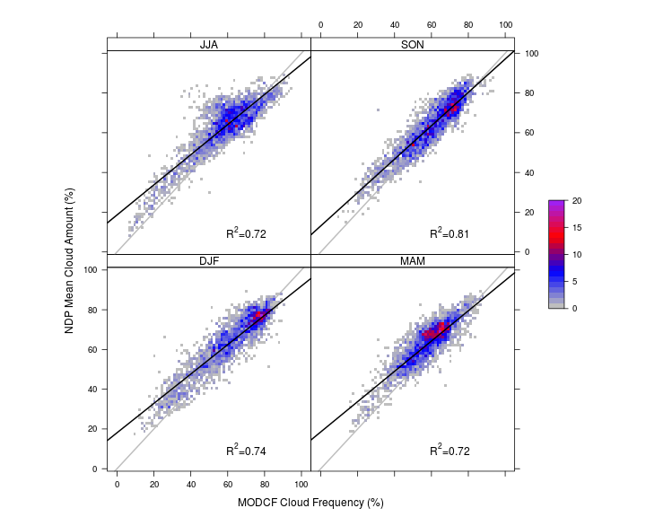

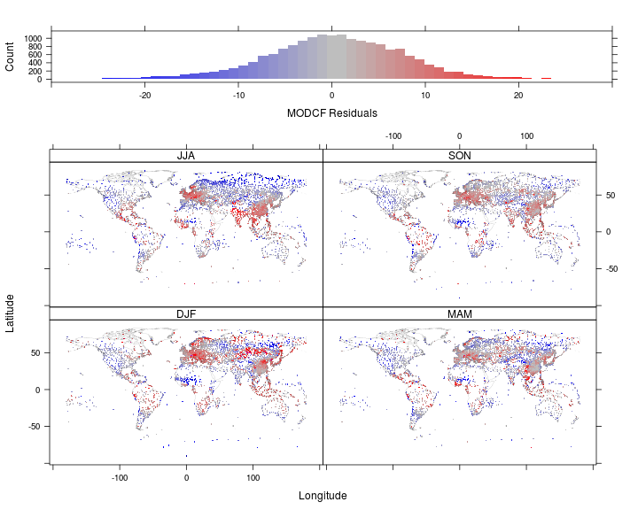

## Temporal Stability

|  | **1970-2009** | **2000-2009** |
| --- | --- | --- |
| Intercept | 14.61 (0.18)*** | 13.41 (0.19)*** |
| MODCF | 0.79 (0.00)*** | 0.80 (0.00)*** |
| R-Squared | 0.81 | 0.78 |
| RMSE | 7.37 | 7.98 |
| n | 17013.00 | 17021.00 |
| ***p < 0.001, **p < 0.01, *p < 0.05 |  |  |

## Latitudinal Bias in MODCF

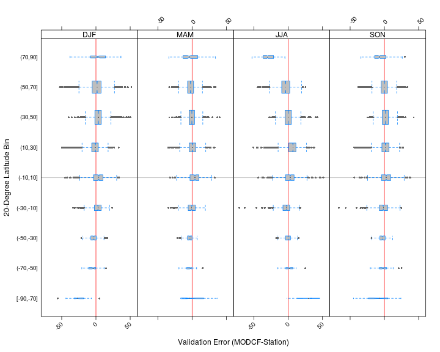

The MODCF tends to overestimate CF at higher latitudes in winter months, and underestimate it in summer months.

|  | seas | [-90,-70] | (-70,-50] | (-50,-30] | (-30,-10] | (-10,10] | (10,30] | (30,50] | (50,70] | (70,90] |
| --- | --- | --- | --- | --- | --- | --- | --- | --- | --- | --- |
| 1 | DJF | 28.6 (20) | 8.8 (62) | 6.8 (440) | 8.4 (776) | 11.6 (865) | 9.9 (2044) | 8.7 (5088) | 11 (3753) | 14.8 (116) |
| 2 | MAM | 16.3 (10) | 8.2 (44) | 6.3 (301) | 8.6 (518) | 10.5 (580) | 8.8 (1363) | 6.7 (3469) | 7.8 (2555) | 14.7 (154) |
| 3 | JJA | 26.1 (3) | 7.3 (69) | 5.5 (601) | 9.1 (1050) | 10.5 (1176) | 10.7 (2725) | 7.4 (6864) | 10.3 (5116) | 31 (336) |
| 4 | SON | 21.2 (17) | 8.5 (64) | 6.5 (443) | 10.3 (787) | 10.7 (881) | 9.5 (2050) | 6.8 (5201) | 7.1 (3898) | 13.3 (239) |

## Assess Land-Use Land-Cover bias

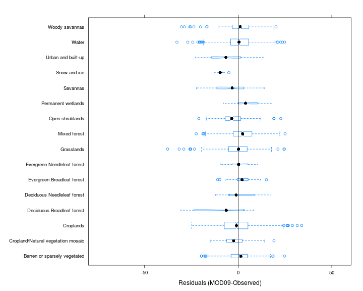

Boxplot showing residuals (MOD09-Station) by land cover type.

Table of RMSE’s (count) by season (column) and Land Cover (row)

| lulcc | DJF | MAM | JJA | SON |
| --- | --- | --- | --- | --- |
| Barren or sparsely vegetated | 7.2 (51) | 6.6 (36) | 10.1 (72) | 6.4 (54) |
| Cropland/Natural vegetation mosaic | 6.7 (38) | 6.1 (27) | 7.1 (56) | 5.8 (41) |
| Croplands | 9.2 (174) | 7.3 (127) | 11.2 (253) | 6.9 (188) |
| Deciduous Broadleaf forest | 4.7 (2) | 16.8 (3) | 20.7 (8) | 12.3 (5) |
| Deciduous Needleleaf forest | 11 (6) | 10.1 (4) | 7.4 (8) | 4.3 (6) |
| Evergreen Broadleaf forest | 5.8 (21) | 2.7 (14) | 6.5 (28) | 4.7 (21) |
| Evergreen Needleleaf forest | 3.5 (4) | 7.7 (3) | 7.3 (8) | 3.2 (6) |
| Grasslands | 6.3 (102) | 7.1 (70) | 10.2 (148) | 6.4 (112) |
| Mixed forest | 9.3 (92) | 6.6 (65) | 10 (132) | 5.9 (97) |
| Open shrublands | 6.7 (52) | 5.9 (38) | 8.5 (76) | 6.5 (57) |
| Permanent wetlands | 12.3 (9) | 5.1 (6) | 8.5 (12) | 3.1 (9) |
| Savannas | 9.3 (15) | 8.1 (10) | 12.1 (20) | 10.4 (15) |
| Snow and ice | 9.5 (3) | 9.6 (2) | 8.7 (4) | 10.9 (3) |
| Urban and built-up | 10.6 (9) | 9.6 (6) | 13.1 (12) | 8.2 (9) |
| Water | 7.3 (164) | 6.5 (112) | 9.5 (226) | 5.7 (171) |
| Woody savannas | 7.2 (58) | 5.8 (41) | 9.8 (81) | 5.8 (60) |
|  | 10 (12364) | 8 (8430) | 10 (16796) | 8.1 (12726) |

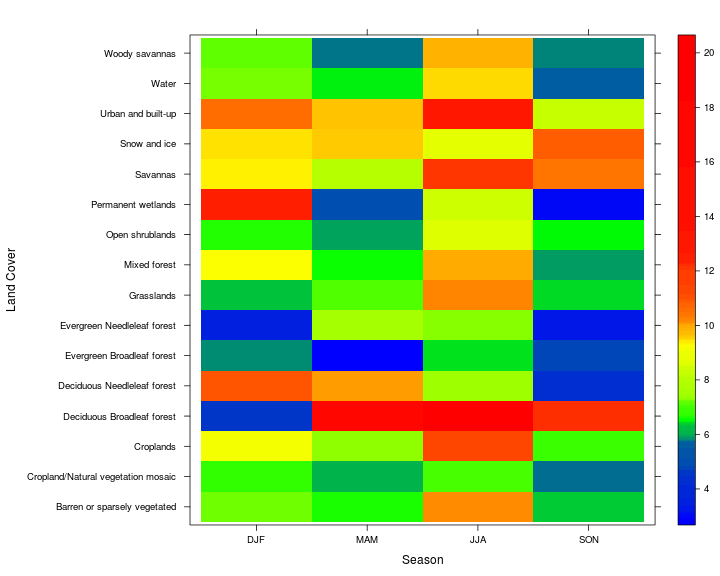